# IST 5535 HW5: Problem 12

Sayantan Majumdar

2020-02-24

## This problem involves writing functions.

### (a) Write a function, Power(), that prints out the result of raising 2 to the 3rd power. In other words, your function should compute $2^3$ and print out the results.

```r
Power <- function() {
  print(2 ^ 3)
}
Power()
```

```
## [1] 8
```

### (b) Create a new function, Power2(), that allows you to pass any two numbers, x and a, and prints out the value of x^a.

```r
Power2 <- function(x, a) {
  print(x ^ a)
}
Power2(3, 8)
```

```
## [1] 6561
```

### (c) Using the Power2() function that you just wrote, compute $10^3$, $8^{17}$, and $131^3$.

```r
Power2(10, 3)
```

```
## [1] 1000
```

```r
Power2(8, 17)
```

```
## [1] 2.2518e+15
```

```r
Power2(131, 3)
```

```
## [1] 2248091
```

### (d) Now create a new function, Power3(), that actually returns the result x^a as an R object, rather than simply printing it to the screen. That is, if you store the value x^a in an object called result within your function, then you can simply return() this result.

```r
Power3 <- function(x, a) {
  result <- x ^ a
  return(result)
}
```

### (e) Now using the Power3() function, create a plot of $f(x) = x^2$. The x-axis should display a range of integers from 1 to 10, and the y-axis should display $x^2$. Label the axes appropriately, and use an appropriate title for the figure. Consider displaying either the x-axis, the y-axis, or both on the log-scale. You can do this by using log=‘‘x’’, log=‘‘y’’, or log=‘‘xy’’ as arguments to the plot() function.

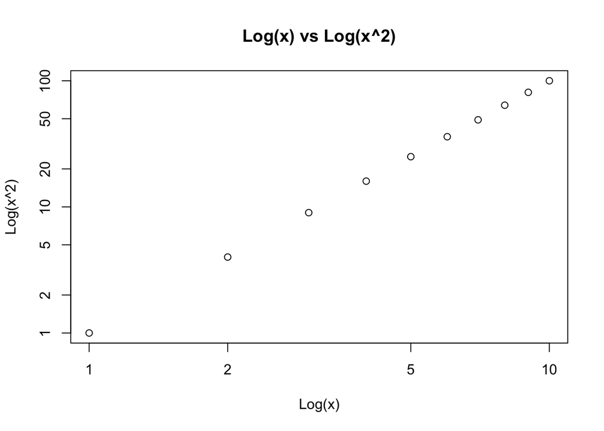

```r
x <- 1:10
plot(x, Power3(x, 2), log = "xy", xlab = "Log(x)", ylab = "Log(x^2)", main = "Log(x) vs Log(x^2)")
```

### (f) Create a function, PlotPower(), that allows you to create a plot of x against x^a for a fixed a and for a range of values of x. For instance, if you call PlotPower (1:10, 3) then a plot should be created with an x-axis taking on values 1, 2, …, 10, and a y-axis taking on values $1^3, 2^3, ..., 10^3$.

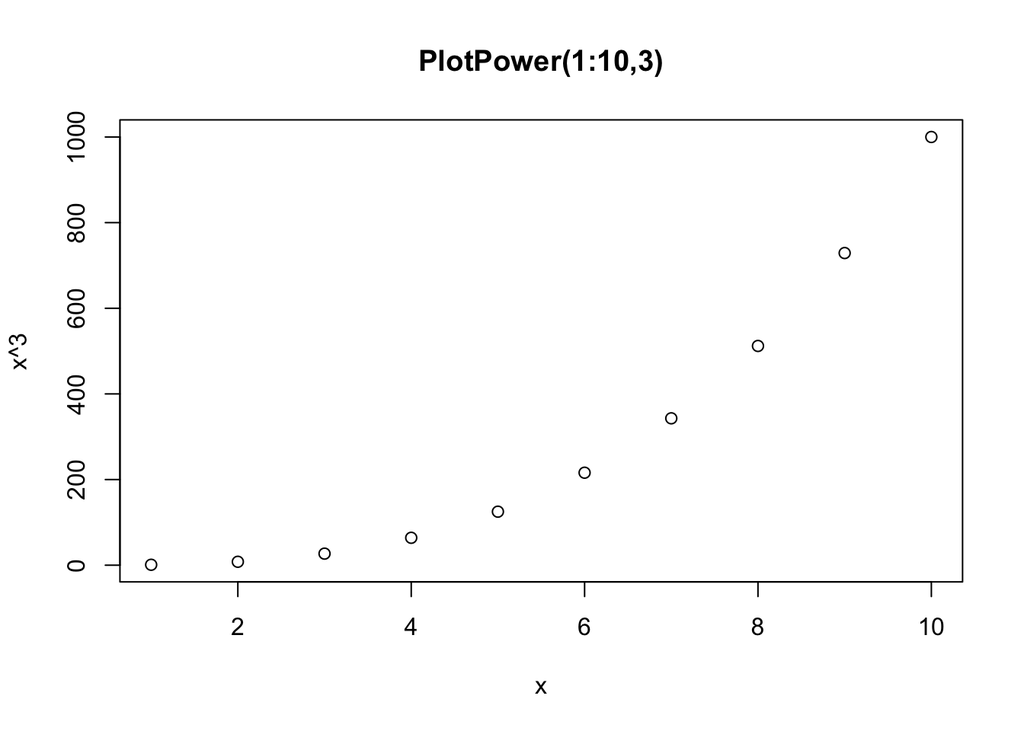

```r
PlotPower <- function(x, a) {
  plot(x, Power3(x, a), xlab = 'x', ylab = paste('x^', a, sep = ''), main = paste('PlotPower(', x[1], ':', x[length(x)], ',', a, ')', sep = ''))
}
PlotPower(1:10, 3)
```